# Customer classification

Customer classification

### 1. Project introduction

This project focuses on **classify whether the customer will buy the stuffs or not** with their **estimated salary** and **age**.

Predicting the characteristics of customers who will buy products in advance is becoming very important for business operators. Thus, our goal is classify **purchased customer** based on their characteristics.

- **Tools:** R (caret / ElemStatLearn / e1071 / kernlab packages)
- **Data:** Social Network Ads data from Kaggle (https://www.kaggle.com/datasets/rakeshrau/social-network-ads)
- **Analyses performed:** Liner SVM

### 2. Data description & exploration

- `Social Network Ads` is a dataset including information about the customer’s several characteristics and he/she purchased a product or not. This dataset consists of **400 observations with 5 variables**, which are `User.ID` ,`Gender`, `Age`, `EstimatedSalary`, and `Purchased` (0: not purchased, 1: purchased).
- The goal is classify whether each customer bought the product or not, so the response variable will be `Purchased`. I will use only `Age` and `EstimatedSalary` variables for classification.

### 3. Pre-processing

- As we can see below, each variable has different numerical ranges. Thus, we need to **scale and center** both covariates before we proceed the analysis.

```
##   Age EstimatedSalary Purchased
## 1  19           19000         0
## 2  35           20000         0
## 3  26           43000         0
## 4  27           57000         0
## 5  19           76000         0
## 6  27           58000         0
```

- Then, the data converted as below:

```
##          Age EstimatedSalary Purchased
## 1 -1.7795688      -1.4881825         0
## 2 -0.2532702      -1.4588544         0
## 3 -1.1118131      -0.7843075         0
## 4 -1.0164195      -0.3737137         0
## 5 -1.7795688       0.1835208         0
## 6 -1.0164195      -0.3443855         0
```

### 4. Fit a linear SVM

- Before fitting a linear SVM, let’s see how the data looks like. The orange dots showed customers purchased a product, and the green dots showed others.

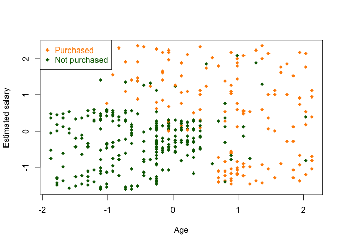

- We can expect that the data could be divided by a single line located in the middle part. The line can be placed anywhere between **green & orange** dots, but we need to find **the optimal line** - which is able to divide all dots the most efficiently. Thus, I tried to fit a linear SVM with `cost = 1`.
- We can see the **confusion matrix** and **classification error rate** as below. The classification error for this model is $15.75$%, so it is pretty reliable.

```
##
##       0   1
##   0 240  46
##   1  17  97
```

```
## [1] 0.1575
```

- Now, I drawed the **decision line** on the plot as below. The decision line is $f(x) = x^T \boldsymbol \beta + \beta_0 = 0$, and this can be calculated by `svm` package. Thus, estimated $\beta$ are $-1.6509$ for `Age` and $-0.9101$ for `EstimatedSalary`. Also, estimated $\beta_0$ is $0.8792$. The decision line was drawn almost exactly as we expected.

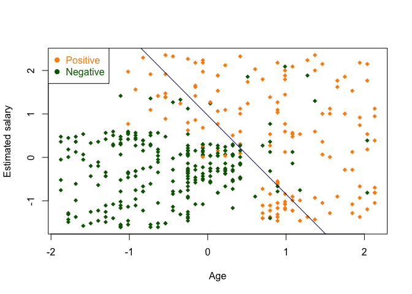

- Now, I marked the **support vectors** to the plot. Support vectors are data points located on the boundary between two classes. Since these data support a decision boundary, it is called a support vector.

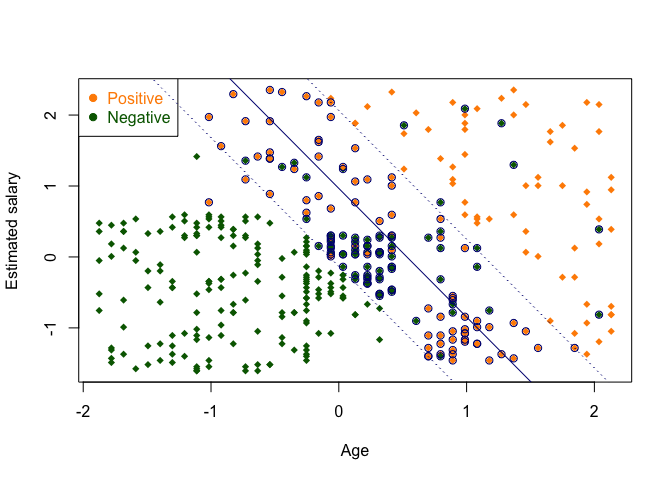

- As we can see, it is impossible to classify all points perfectly. Thus, we need to approve a little error by adjust *C (cost)*. I used $1$ as *C* before, so I tried to change *C* to $100$ and $0.01$ as below (in order):

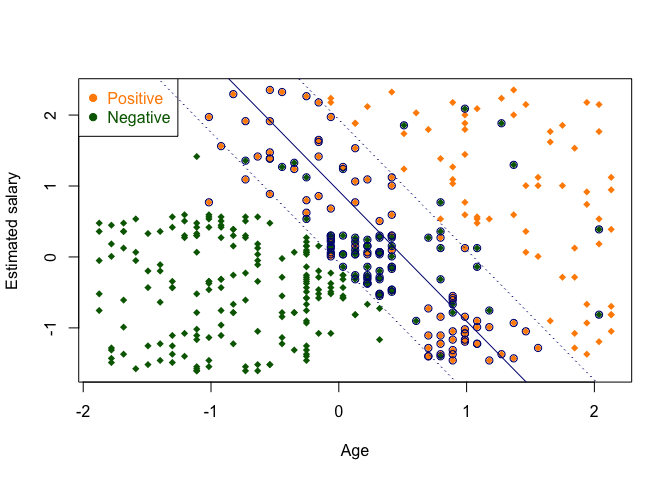

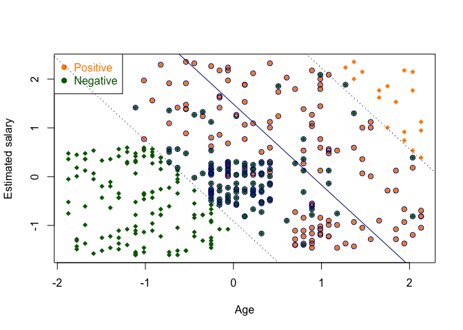

[output not shown]

### 5. Conclusion

- From the analysis, **the linear SVM** classified customer pretty well based on their characteristics (`Age` and `EstimatedSalary`) when *C (cost)* = $1$. However, the classification results could be changed when we adjust *C*. Thus, we need to find the define *C* for each situation.
- Since we performed those classification method only with two variables, this **SVM** would be improved its classification ability if we use more characteristics of the customers, such as `Gender`.